# Oppslutningen om veldferdsstaten

NOU 2011:7, kap 13

Mikko Moilanen

29/04/2026

# Oppslutningen om velferdsstaten

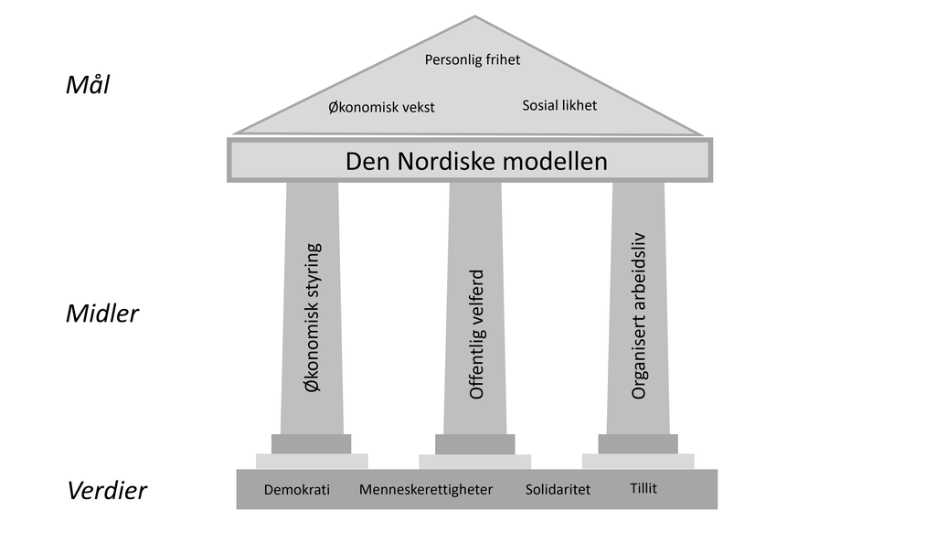

## Velferdsstaten og tillit: Nordiske land har høy mellommenneskelig tillit

[interactive chart not shown]

## Velferdsstaten og tillit: velferdsstaten kan fremme og vedlikeholde tillit

[interactive chart not shown]

- Universelle velferdsregimer reduserer skillet mellom «oss» og «dem»
- Gratispassasjerproblem:
  - Velferdsstaten er avhengig av at hver enkelt har en tillit til at «alle de andre» også vil legge pengene sine i den felles potten
  - Hvis ikke, risikerer den enkelte å tape pengene han selv har lagt i felleskassa, samtidig som de som beholdt pengene selv kom bedre ut

## Viktigheten av oppslutning

- Inntektssikringsordninger krever bred oppslutning for å fungere effektivt
- Misnøye kan eksistere samtidig som reglene og lovene må følges
- Langsiktig systemoverlevelse til tross for misnøye
  - man slipper ikke å betale skatt eller trygdeavgift selv om man er uenig i måten pengene brukes på
- Misnøye kan føre til politisk endring
  - kan omformes til politiske programmer
  - endringer i partienes prioteringer
- Innvandringsfiendtlig retorikk kan forsterke skepsis
- Meningsmålinger kan indikere tidlig misnøye

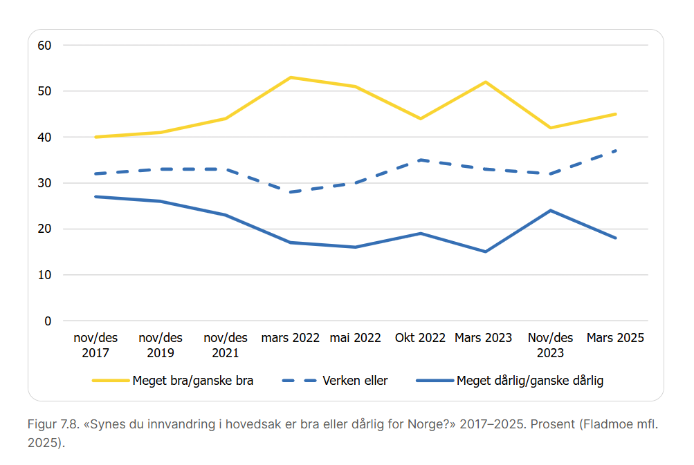

- Høy oppslutning forenkler kontroll og administrasjon av velferdsordningene
  - Følging av regler baseres på oppfatningen om at det er “riktig”
  - Oppslutning bidrar til opprettholdelse av et system sett som godt og riktig

## Konsekvenser av svak oppslutning

- Svak oppslutning svekker viljen til å bidra
- Regler og kontroll blir fremtredende
- Trussel om straff kan øke hvis oppslutningen er lav
- Risiko for økende systemmanipulasjon
  - stadig jakt etter muligheter til å lure systemet

## Legitimitet og velferdsstatens bærekraft

- Legitimitet er forutsetningen for bærekraften til systemet
- Oppslutningen sikrer systemets langvarige levedyktighet

## Public Goods Game

- Hver deltaker får **10 poeng** i hver runde.
- Du velger hvor mange poeng du vil legge i **felleskassen**.
- Poengene du **ikke** legger i felleskassen, beholder du selv.
  - målet er å oppnå høyest mulig gevinst for deg selv
- Alle poeng i felleskassen blir multiplisert med **1,5**.
- fellespotten deles deretter **likt mellom alle deltakerne**.

$$\text{Din gevinst}
=
(10 - \text{ditt bidrag})
+
\frac{1.5 \times \text{samlet bidrag}}{\text{antall deltakere}}$$

## Spørreskjema

[figure not shown]

# Økende mangfold som velferdsstatlig legitimitetsproblem

## Hvorfor er økende mangfold en utfordring?

- Økende mangfold kan potensielt svekke velferdsstatens legitimitet
- Spørsmål om grensedragning, samhørighet og gjensidighet er kritiske
- Fellesskapsfølelse fremmer viljen til å bidra til det felles gode

## Holdninger til innvandrere og innvandring: velferdsgoder

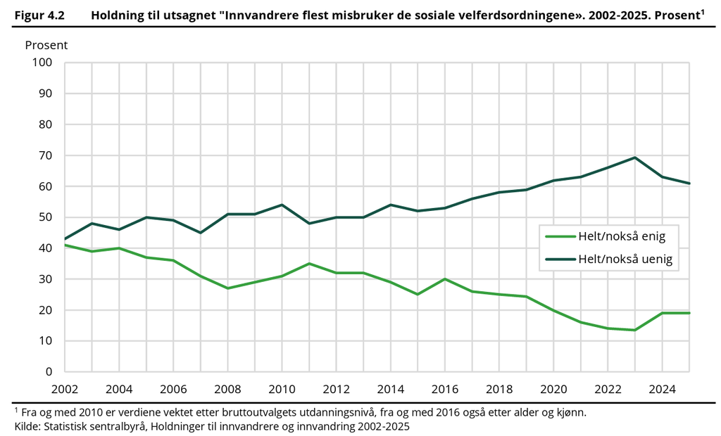

## Betingelser for at fellesskap skal opprettholdes

1. **Kontroll**:man opplever at systemet har kontroll over omfordeling
- adgangen til rettigheter og plikter er klart definert
2. **Gjensidighet**: man opplever at alle bidrar etter evne:
- “Jeg betaler for deg, du betaler for meg.”
3. **Det opplevde fellesskapet**: man opplever en tilhørighet til fellesskapet
- enten det er etnisk, nasjonal, eller annen tilknytning

### Kontroll

- Staten kan ikke ha åpne grenser og samtidig gi sterke rettigheter til alle
- Nødvendige restriksjoner for å bevare velferdsstatens legitimitet og bærekraft
- Et land som søker å kombinere fri innvandring med sjenerøse og universelle ytelser, vil sannsynligvis oppleve problemer med oppslutning om velferdsordningen i den generelle befolkningen.

### Gjensidighet

- Velferdsstatens bærekraft avhenger av gjensidig forpliktelse til bidrag og risikodeling
  - et system for risikodeling, og mange av ytelser kan forstås som forsikringsordninger
- Mistenksomhet mot innvandreres bidrag kan svekke systemets legitimitet
- Majoriteten kan være lite innstilt på å være med å betale for beskyttelse mot risikoer de selv har liten sannsynlighet for å oppleve
  - Grunntanken i velferdsstaten: velferdsstatene er basert på en opplevelse av å være i samme båt

### Det opplevde fellesskapet

- Større vilje til omfordeling hvis mottakeren oppfattes som en av “oss”
  - mennesker er mer villige til å gi opp deler av inntekten sin til fellesskapet hvis den som mottar fellesskapsgoder er en som ser ut som, og oppfører seg som, dem selv
  - forestillingen om det nasjonale fellesskapet vs. økt mangfold
    - velferdsstatsprosjektet kan vakle
- nasjonale fellesskap og utgruppeskepsis spiller en rolle i opprettholdelsen av velferdsordninger
- Forestilinger om naturgitte fellesskap kan ha en betydelig retorisk kraft, og brukes av innvandringsskeptiske politikere i flere land
- [velferdssjåvinisme-hypotesen](https://brill.com/view/journals/ijgr/29/4/article-p777_008.xml)
  - USA:
    - velferd er greit, så lenge den går til personer av egen gruppe
  - Vesten:
    - personer som allerede er skeptisk til personer fra andre etniske grupper blir mer skeptiske til ulike velferdsholdninger når andelen innvandrere er høy
    - de som ikke har noe imot innvandrere er mer vennlig innstilt til ulike velferdsordninger, også for innvandrerne

## Konsekvenser av økt mangfold

- Innvandring utfordrer ideen om “the bounded world”
- Utrygghet rundt grensekontroll kan minske støtte til velferdsstaten
- Innvandreres og utvandreres bidrag til fellesskapet er avgjørende for oppfatningen av rettferdighet og gjensidighet

## Oppsummering

- Økende mangfold utfordrer velferdsstatens legitimitet gjennom spørsmål om samhørighet og rettferdig fordeling
- Et balansert kontrollregime og klare betingelser for tilgang til velferdsgoder er viktig for å opprettholde støtten
- Gjensidig forpliktelse og opplevelsen av nasjonalt fellesskap spiller sentrale roller for velferdsstatens aksept i befolkningen

## Sosial kapital

- **Sosial kapital**: nøkkelbegrep i samfunnsvitenskap
- Definisjon (Putnam): Sosiale nettverk, gjensidighet og **tillit**
- Sentrale spørsmål:
  - Hvordan påvirker økende mangfold den sosiale kapitalen i et samfunn?
    - Forholdet mellom etnisk mangfold og sosial kapital
    - Påvirkning av mangfold på samfunnets sosiale kapital

### Teoretiske perspektiver

- Konfliktteori:
  - Heterogenitet fremmer **inngruppesolidaritet** og **utgruppeskepsis**
- Kontaktteori:
  - Mer kontakt med etnisk ulike personer øker gjensidig tillit
- Empirisk støtte for begge teorier

### Putnams konklusjoner om multietniske nabolag

- Kortsiktig spenning mellom mangfold og samhørighet
- Langsiktig potensial for økt toleranse for mangfold
- Implikasjoner for velferdsstaten:
  - Tilbaketrekning og mindre deltakelse i felles prosjekter
  - Mindre vilje til å finansiere felles goder

## En todelt velferdsstat?

- Velferdsstaten er populær i Norge, og manglende oppslutning framstår ikke som et presserende problem
- Støtte for en todelt velferdsstat blant en tredjedel av norske velgere
  - ønske om å reservere ytelser for ikke-innvandrere
  - det kan være tilslutning til å begrense velferdsstatens ordninger til personer som har bodd i landet i et visst antall år
  - **hvem som skal inkluderes og ekskluderes?**
  - en modernisert utgave av en gammel problematikk i velferdsdebatten: Skal man skille mellom en «verdig» og en «ikke verdig» trengende, og når er man eventuelt «verdig»?
- utviklingen i holdninger til økt mangfold når det gjelder velferdsstaten vil avhenge av
  - størrelsen på innvandringen
  - innvandrernes deltakelse på arbeidsmarkedet og stønadsbruk
  - omfanget av stønadseksport